# Gerstung Epigenetics as category - Added Protocol Year

Salma Abdelbaky

23/1/2023

```r
#install.packages("usethis")
#install.packages("rmarkdown")

library(devtools)
#library(msSurv)
library(rmarkdown)


#install_github("mg14/mg14")
#install_github("mg14/CoxHD/CoxHD")

library(CoxHD)
library(mg14)
library(DT)
library(htmlwidgets)
library(tinytex)
library(dplyr)


drop <- c("list_id","Sample","PATID")
drop_samp <- c("list_id","PATID")

sampleNames <- read.csv("Alliance_sampleids_final.csv", header = TRUE,
                        check.names = FALSE, stringsAsFactors = FALSE)

sampleNames_new <-  sampleNames[,!(names(sampleNames) %in% drop_samp)]


MinOccurances = 25


## Clinical Data
Clinical = read.csv("Alliance_clincial_final.csv", header = TRUE, check.names = FALSE, stringsAsFactors = FALSE)
rownames(Clinical) <- Clinical$Sample
Clin_new <-  Clinical[,!(names(Clinical) %in% drop)]


#Epitype
Epitype = read.csv("Alliance_epitype_final.csv", header = TRUE, check.names = FALSE, stringsAsFactors = FALSE)
rownames(Epitype) <- Epitype$Sample
Epitype_new <-  Epitype[,!(names(Epitype) %in% drop)]
for (i in 1:ncol(Epitype_new)){Epitype_new[,i] <- as.numeric(Epitype_new[,i])}


## Genetics
Genetics = read.csv("Alliance_genetics_JK21_a.csv", header = TRUE,
                    check.names = FALSE, stringsAsFactors = FALSE)

rownames(Genetics) <- Genetics$Sample

Gen_new = Genetics[,!(names(Genetics) %in% drop)]
n <- which(colnames(Gen_new) == "CEBPA_mono" | colnames(Gen_new) == "CEBPA_bi")
Gen_new <- Gen_new[,-n]



## Cytogenetics
Cytogenetics = read.csv("Alliance_cytogenetics_final.csv", header = TRUE,
                        check.names = FALSE, stringsAsFactors = FALSE)
rownames(Cytogenetics) <- Cytogenetics$Sample

Cyto_new <- Cytogenetics[,!(names(Cytogenetics) %in% drop)]


## Demographics
Demographics = read.csv("Alliance_demographics_final.csv", header = TRUE,
                        check.names = FALSE, stringsAsFactors = FALSE)
rownames(Demographics) <- Demographics$Sample
Dem_new <- Demographics[,!(names(Demographics) %in% drop)]



#this is set so it will count the number of occurrences and not just non NA cells later for n in Wald test
#Clin_new$Splenomegaly[Clin_new$Splenomegaly == 0] <- NA
#Clin_new$tAML[Clin_new$tAML == 0] <- NA



## Nuisance and Annotation
Nuisance = read.csv("detailed data about age and protocol.csv", header = TRUE, check.names = FALSE, stringsAsFactors = FALSE)
rownames(Nuisance) <- Nuisance$Sample_Id
colnames(Nuisance)[1] <- "Sample"
Nuisance <- as.data.frame(Nuisance[,-c(4,6)])
Nuisance_new <-  as.data.frame(Nuisance[,!(names(Nuisance) %in% drop)])
rownames(Nuisance_new) <- gsub("*  EXTRA*","",rownames(Nuisance_new))

library(dplyr)
Nuisance_new <- filter(Nuisance_new, rownames(Nuisance_new) %in% rownames(Epitype_new))
unique(Nuisance_new$PROTOCOL)
```

```
##  [1]  8361  8525  8721  8821  8923  9022  9120  9222  9420  9621  9720 10201
## [13] 10502 10503 10603 11001 11002 19808
```

```r
Annotation = read.csv("Annotated data n=1266 JK incl. ELN2022,bzip,drugtx 12212022.csv", header = TRUE, check.names = FALSE, stringsAsFactors = FALSE, row.names = 1)
Annotation_new <- as.data.frame(Annotation[rownames(Epitype_new),])
Nuisance_new <- transform(merge(Annotation_new["drug"], Nuisance_new, by = 0, all = TRUE), row.names = 1)
colnames(Nuisance_new)[1] <- "Drug"

Nuisance_new <- transform(merge(Epitype_new, Nuisance_new, by = 0, all = TRUE), row.names = 1)
Nuisance_new <- transform(merge(Epitype_new, Nuisance_new, by = 0), row.names = 1)

Nuisance_new <- Nuisance_new[ ,c("Drug", "PROTOCOL")]

library(mltools) ## creating dummy columns
library(data.table)

#Nuisance_new$PROTOCOL <- as.factor(Nuisance_new$PROTOCOL)
##Nuisance_new$Drug <- as.factor(Nuisance_new$Drug)
#rowz <- rownames(Nuisance_new)
#newdata <- as.data.frame(one_hot(as.data.table(Nuisance_new["PROTOCOL"])))
#rownames(newdata) <- rowz

#sumz <- colSums(newdata, na.rm = T)

## Keep only the 7 protocols

#newdata <- newdata[,c("PROTOCOL_8525", "PROTOCOL_8821", "PROTOCOL_9022", "PROTOCOL_9720", "PROTOCOL_10503", "PROTOCOL_10603", "PROTOCOL_11002", "PROTOCOL_19808")]

#Nuisance_new <- newdata
#Nuisance_new <-  as.data.frame(Nuisance_new[,!(names(Nuisance_new) %in% drop)])

Nuisance <- Nuisance_new

Nuisance$protocolyear <- substr(Nuisance$PROTOCOL, 1, 2)
Nuisance$protocolyear <- ifelse(Nuisance$protocolyear == 19, "01", Nuisance$protocolyear)
Nuisance$protocolyear <- ifelse(Nuisance$PROTOCOL  == 10201, "04", Nuisance$protocolyear)

Nuisance$Protocol_Year <- ifelse(Nuisance$protocolyear %in% c("01", "04", 10, 11), 1, 0)

Nuisance <- filter(Nuisance, rownames(Nuisance) %in% rownames(Nuisance_new))
Nuisance <- Nuisance["Protocol_Year"]
Nuisance_new <- Nuisance
for (i in 1:ncol(Nuisance_new)){Nuisance_new[,i] <- as.numeric(Nuisance_new[,i])}

## Adding new bzip annotation

Gen_new2 <- cbind(Gen_new, Annotation_new[c("cebpa_bzip", "cebpa_other")])
Gen_new <- Gen_new2


Clin_new <- transform(merge(Clin_new, Nuisance_new, by = 0), row.names =1)

dataList <-list(Gen_new,
                Dem_new,
                Clin_new,
                Cyto_new,
                Epitype_new
                )


names(dataList) <- c("Genetics", "Demographics", "Clinical","Cytogenetics",  "Epitype")

## Filteration

library(dplyr)

for(i in 1 :5){
  dataList[[i]] <- filter(dataList[[i]], rownames(dataList[[i]]) %in% rownames(Clin_new))
}
```

making the interactions set and other things to get data together no epi/cyto or epi/genetic interactions

```r
dataList$GeneGene <- MakeInteractions(data.frame(dataList$Genetics),
                          data.frame(dataList$Genetics))[,as.vector(upper.tri(matrix(0,ncol=ncol(dataList$Genetics),
                                                                                                nrow=ncol(dataList$Genetics))))]
dataList$GeneGene <- dataList$GeneGene[,colSums(dataList$GeneGene, na.rm=TRUE)>0]
dataList$GeneGene$`NPM1:FLT3_ITD:DNMT3A` <- (rowSums(dataList$Genetics[c('NPM1',"FLT3_ITD","DNMT3A")])==3)+0
## Add NPM1:FLT3_ITD:DNMT3A product term as well


dataList$CytoCyto <- MakeInteractions(dataList$Cytogenetics,        dataList$Cytogenetics)[,sapply(1:ncol(dataList$Cytogenetics), `<`,1:ncol(dataList$Cytogenetics))]

dataList$CytoCyto <- dataList$CytoCyto[, colSums(dataList$CytoCyto, na.rm=TRUE) > 0]
dataList$GeneCyto <- MakeInteractions(dataList$Genetics, dataList$Cytogenetics)
dataList$GeneCyto <- dataList$GeneCyto[,colSums(dataList$GeneCyto, na.rm=TRUE) > 0]

dataRaw <- do.call(cbind,dataList)
names(dataRaw) <- unlist(sapply(dataList, names))
dataFrame <- StandardizeMagnitude(dataRaw)
#dataFrame <- dataRaw
dim(dataFrame)
```

```
## [1] 1021 1291
```

```r
groups <- unlist(sapply(names(dataList), function(x) rep(x, ncol(dataList[[x]]))))
groups[grepl("^(t_)|(inv)", colnames(dataFrame)) &! grepl(":", colnames(dataFrame))] <- "Fusions"
groups[groups=="Cytogenetics"] <- "CNA"
groups <- factor(groups)
names(groups) <- colnames(dataFrame)
table(groups)
```

```
## groups
##     Clinical          CNA     CytoCyto Demographics      Epitype      Fusions
##           10           18          153            2           13            5
##     GeneCyto     GeneGene     Genetics
##          510          541           39
```

imputation

```r
#Poor man's imputation by column means

rowss <- rownames(dataFrame)
poorMansImpute <- function(x) {x[is.na(x)] <- mean(x, na.rm=TRUE); return(x)}
dataFrame <- as.data.frame(sapply(dataFrame, poorMansImpute))
rownames(dataFrame) <- rowss
```

outcome data

```r
osDATA <- read.csv("Alliance_outcome_final.csv", header = TRUE, check.names = FALSE, stringsAsFactors = FALSE)
#head(osDATA)
rownames(osDATA) <- osDATA$Sample
osDATA <- filter(osDATA, rownames(osDATA) %in% rownames(Clin_new))

#osDATA <- filter(osDATA, !rownames(osDATA) %in% patientsdrop)



#@we didn't change this to a new variable.  I needed to drop the one APL patient, so I used osdata2 for a minute
osDATA <- osDATA[,!(names(osDATA) %in% drop)]

#head(osDATA)

for (i in 2:ncol(osDATA)){osDATA[,i] <- as.numeric(as.character(osDATA[,i]))}

#Looking at OS data:


osDATA[,3] <- osDATA[,2]/365
colnames(osDATA)[3] <- "OSyr"


os <- Surv(osDATA$OS, osDATA$STATUS) #OS
osTD <-  Surv(time = rep(0, nrow(osDATA)), time2=osDATA$OS, event=osDATA$STATUS )

osYr <- Surv(osDATA$OSyr, osDATA$STATUS) #OS
osYrTD <-  Surv(time = rep(0, nrow(osDATA)), time2=osDATA$OSyr, event=osDATA$STATUS )

#Column 2 is the OS (survyr).
osYrTD[,1] <- osYrTD[,1]/365
```

color set

```r
set1 <- brewer.pal(9, "Set1")
```

2.3.1 Number of oncogenic mutations

```r
dataFrameOsTD <- dataFrame


#Define some indexes relating to subsets of variables used by the random effects model.
mainGroups <- grep("[A-Z][a-z]+[A-Z]",levels(groups), invert=TRUE, value=TRUE)
mainGroups
```

```
## [1] "Clinical"     "CNA"          "Demographics" "Epitype"      "Fusions"
## [6] "Genetics"
```

```r
mainIdx <- groups %in% mainGroups
osIdx <- !grepl("TPL", colnames(dataFrame)) ## Exclude TPL from OS analyses..
whichRFXOs <- which((colSums(dataFrame)>=MinOccurances | mainIdx) & osIdx) # ie, > 0.5%
mainIdxOs <- mainIdx & osIdx
osTDIdx <- !grepl("TPL_efs", colnames(dataFrame))
whichRFXOsTD <- which((colSums(dataFrame)>=MinOccurances | mainIdx) & osTDIdx) # ie, > 0.5%
mainIdxOsTD <- mainIdx & osTDIdx
whichRFXOsGG <- which((colSums(dataFrame)>=MinOccurances | mainIdxOs) & osIdx &
                        groups %in% c(mainGroups,"GeneGene", "GeneCyto")) # ie, > 0.5%

#Compute the number of oncogenics, excluding complex karyotype.
NONC <- rowSums(cbind(dataList$Cytogenetics[names(dataList$Cytogenetics)!="complex"],
                      dataList$Genetics), na.rm=TRUE)

NONCs <- factor(ceiling(pmin(NONC,6)/2), labels=c("0-1","2-3","4-6","7+"))
c <- set1[c(3,2,4,1,5)]
f <- survfit(osYr ~ NONCs)
```

survival plot

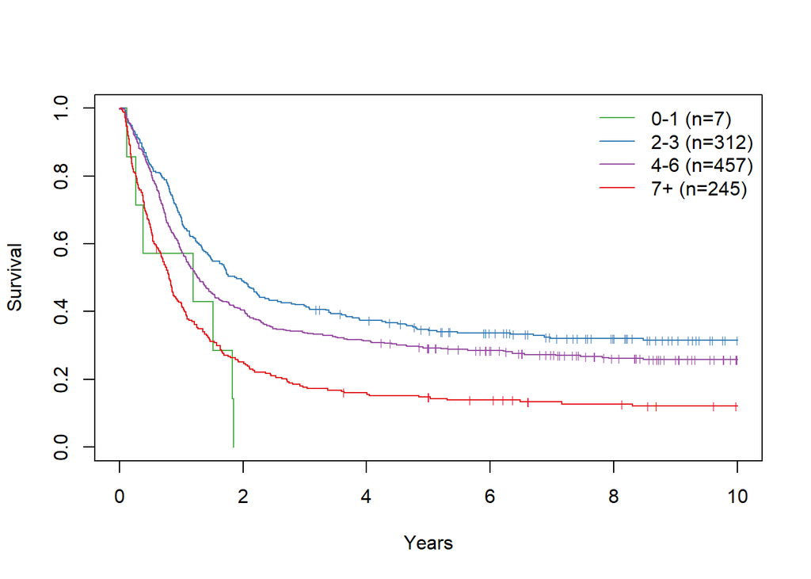

```r
s <- summary(f)
plot(f, col=c, xlim=c(0,10),xlab="Years", ylab="Survival",mark="|", cex=.5)
legend('topright', bty='n', col=c, legend=paste0(levels(NONCs)," (n=",table(NONCs),")"), lty=1)
```

2.3.1.1.1 Linearity of continuous variables Fit a spline through continuous covariates

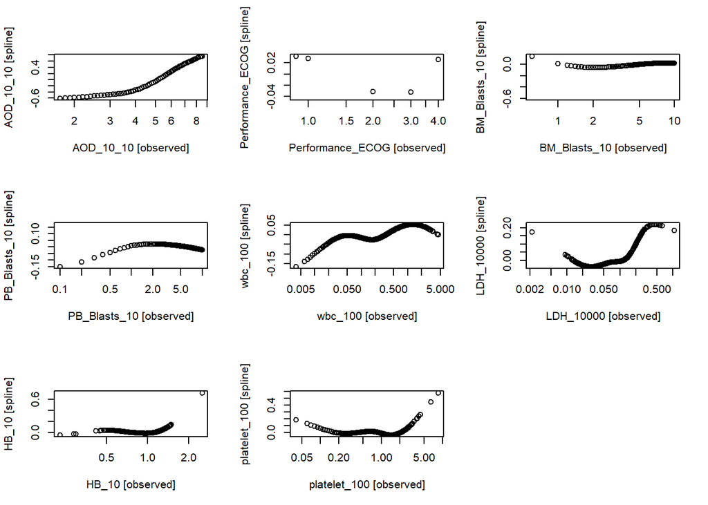

```r
set.seed(42)
trainIdx <- sample(c(TRUE,FALSE), nrow(dataFrame), replace=TRUE, prob=c(0.66,0.34))
trainIdxOsTD <- trainIdx
par(mfrow=c(3,3))
clinicalSpline <- as.data.frame(sapply(dataFrame[groups %in% c("Clinical","Demographics")], function(x){
  if(all(x[1:5] %in% 0:10)) return(x)
  y <- log(x+min(x)+1e-3)
  fit <- coxph(os ~ pspline(y, df=3), subset=trainIdx)
  predict(fit, newdata=data.frame(y=y))
}))
for(n in names(clinicalSpline)) if(!all(dataFrame[1:5,n] %in% 0:10))
  plot(dataFrame[,n], clinicalSpline[,n], log='x', xlab=paste(n, '[observed]'), ylab = paste(n, '[spline]'))
```

concordance

```r
summary(coxph(os ~ ., data=clinicalSpline, subset=!trainIdx))$concordance
```

```
##          C      se(C)
## 0.61996851 0.01777571
```

```r
###copy output###

summary(coxph(os ~ ., data=dataFrame[groups %in% c("Clinical","Demographics")]), subset=!trainIdx)$concordance
```

```
##          C      se(C)
## 0.60972240 0.01041901
```

```r
###copy output###

survConcordance(os[!trainIdx] ~ predict(coxph(os ~ ., data=clinicalSpline, subset=trainIdx),
                                        newdata = clinicalSpline[!trainIdx,]))
```

```
## $concordance
## concordant
##  0.5817714
##
## $stats
## concordant discordant  tied.risk  tied.time   std(c-d)
##  30294.000  21778.000      0.000     33.000   2019.279
##
## $n
## [1] 334
##
## $std.err
##   std(c-d)
## 0.01938929
##
## $call
## survConcordance(formula = os[!trainIdx] ~ predict(coxph(os ~
##     ., data = clinicalSpline, subset = trainIdx), newdata = clinicalSpline[!trainIdx,
##     ]))
##
## attr(,"class")
## [1] "survConcordance"
```

```r
survConcordance(os[!trainIdx] ~ predict(coxph(os ~ ., data=dataFrame[groups %in% c("Clinical","Demographics")],
                                              subset=trainIdx), newdata = dataFrame[!trainIdx,]))
```

```
## $concordance
## concordant
##  0.5894147
##
## $stats
## concordant discordant  tied.risk  tied.time   std(c-d)
##  30692.000  21380.000      0.000     33.000   2019.279
##
## $n
## [1] 334
##
## $std.err
##   std(c-d)
## 0.01938929
##
## $call
## survConcordance(formula = os[!trainIdx] ~ predict(coxph(os ~
##     ., data = dataFrame[groups %in% c("Clinical", "Demographics")],
##     subset = trainIdx), newdata = dataFrame[!trainIdx, ]))
##
## attr(,"class")
## [1] "survConcordance"
```

2.3.2 Random effects models

```r
#Here we fit the random effects model using our implementation in the CoxHD package. First for main effects only
coxRFXFitOsTDMain <- CoxRFX(dataFrameOsTD[,mainIdxOsTD], osTD, groups[mainIdxOsTD], verbose = TRUE, max.iter = 100)
```

[output not shown]

```r
#Now including gene:gene interaction terms (min. recurrence = 8)
whichRFXOsTDGG <- which((colSums(dataFrame)>=MinOccurances | mainIdxOsTD)
                        & osTDIdx & groups %in% c(mainGroups,"GeneGene"))
coxRFXFitOsTDGGc <- CoxRFX(dataFrameOsTD[,whichRFXOsTDGG], osTD, groups[whichRFXOsTDGG],
                           which.mu=mainGroups, verbose = TRUE, max.iter = 100)
```

[output not shown]

[output cut: 17 more lines]

[output not shown]

```r
## allow only the main groups to have mean different from zero..


#Compute Harrel's concordance index

################## make sure it is finished running before continuing#################
###copy output###
```

more concordance

```r
survConcordance(osTD~coxRFXFitOsTDGGc$linear.predictors)
```

```
## $concordance
## concordant
##  0.7207105
##
## $stats
## concordant discordant  tied.risk  tied.time   std(c-d)
##  351030.00  136031.00       0.00     345.00   10788.39
##
## $n
## [1] 1021
##
## $std.err
##   std(c-d)
## 0.01107499
##
## $call
## survConcordance(formula = osTD ~ coxRFXFitOsTDGGc$linear.predictors)
##
## attr(,"class")
## [1] "survConcordance"
```

```r
survConcordance(osTD~coxRFXFitOsTDMain$linear.predictors)
```

```
## $concordance
## concordant
##  0.7185691
##
## $stats
## concordant discordant  tied.risk  tied.time   std(c-d)
##  349987.00  137074.00       0.00     345.00   10788.39
##
## $n
## [1] 1021
##
## $std.err
##   std(c-d)
## 0.01107499
##
## $call
## survConcordance(formula = osTD ~ coxRFXFitOsTDMain$linear.predictors)
##
## attr(,"class")
## [1] "survConcordance"
```

2.3.2.1 Variance components Here we compute the variance components.

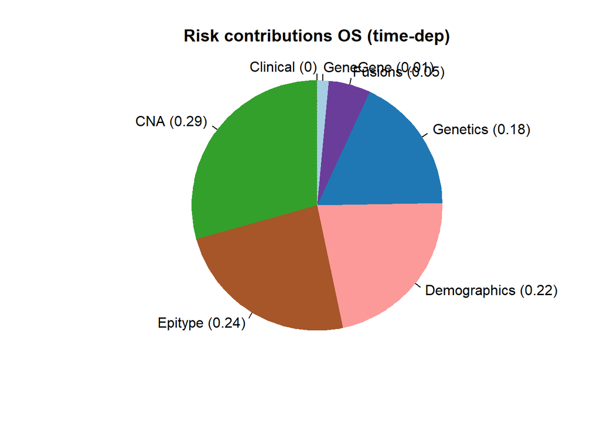

```r
colGroups <- c("#E41A1C" , "#33A02C", "#FF7F00", "#FB9A99", "#A65628", "#6A3D9A", "#999999", "#A6CEE3", "#1F78B4", '#DAA520')

names(colGroups) <- levels(groups)[order(toupper(levels(groups)))]

Fig1<-PlotVarianceComponents(coxRFXFitOsTDGGc, col=colGroups,absolute = FALSE)
title("Risk contributions OS (time-dep)")
```

```r
#pdf(Fig1)
#dev.print(pdf, file="filename.pdf")
```

2.3.3 Confidence intervals and significance tests Estimate confidence intervals by parametric bootstrap and compare with Wald Test. Note that the usual sample with replacement yields inconsistencies for the interaction terms due to the overdispersed correlations. The theoretical description of the survival time simulation is given in section survival. TAKES A WHILE TO RUN

```r
set.seed(42)
risk <- as.matrix(dataFrame[whichRFXOsTDGG]) %*% coxRFXFitOsTDGGc$coefficients
risk <- risk - mean(risk)
```

```r
SimSurvNonpS <- function(risk, surv, H0 = basehaz(coxph(surv ~ 1))) {
H0 = basehaz(coxph(os ~ 1))
FHazInv <- splinefun(c(0,H0$hazard), c(0,H0$time), method="monoH.FC", ties=min)
n = length(risk)
deathTimes = FHazInv(rexp(n, exp(risk))) #predict(hazardDist, rexp(n, exp(risk))) }

f <- os
f[,2] <- 1-f[,2]
F <- survfit(f~1)
FCensInv <- splinefun(F$surv, F$time, ties=min )
censTimes <- FCensInv(runif(n,0,1)) ## Simulate censoring times

survOut <-  Surv(time = pmax(0,pmin(deathTimes, censTimes)), event=(deathTimes < censTimes)+0)
return(survOut) }
```

```r
load(file = "parBootNuisbZIPEpi_protocolyear.Rda")
```

Distributions of mean, sigma and df

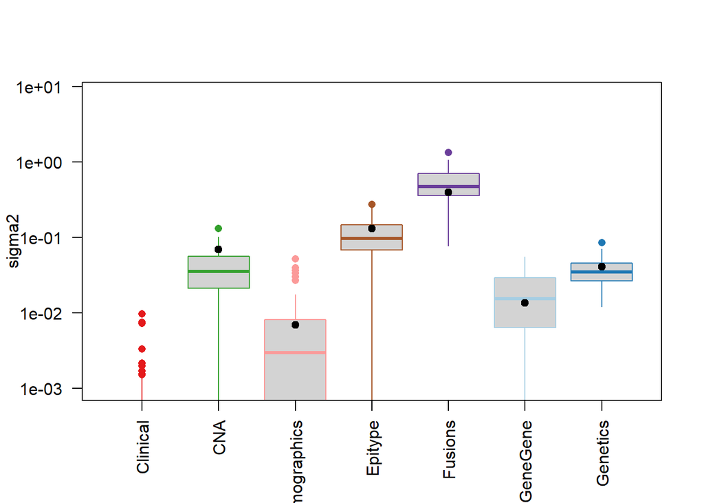

```r
#Distributions of mean, sigma and df
boxplot(t(sapply(parBoot, `[[`, "sigma2")), border=colGroups[names(parBoot[[1]]$sigma2)], lty=1, pch=16, staplewex=0, ylab="sigma2", las=2, log="y", ylim=c(1e-3,8))
abline(h=0, lty=3)
points(coxRFXFitOsTDGGc$sigma2,  pch=19)
```

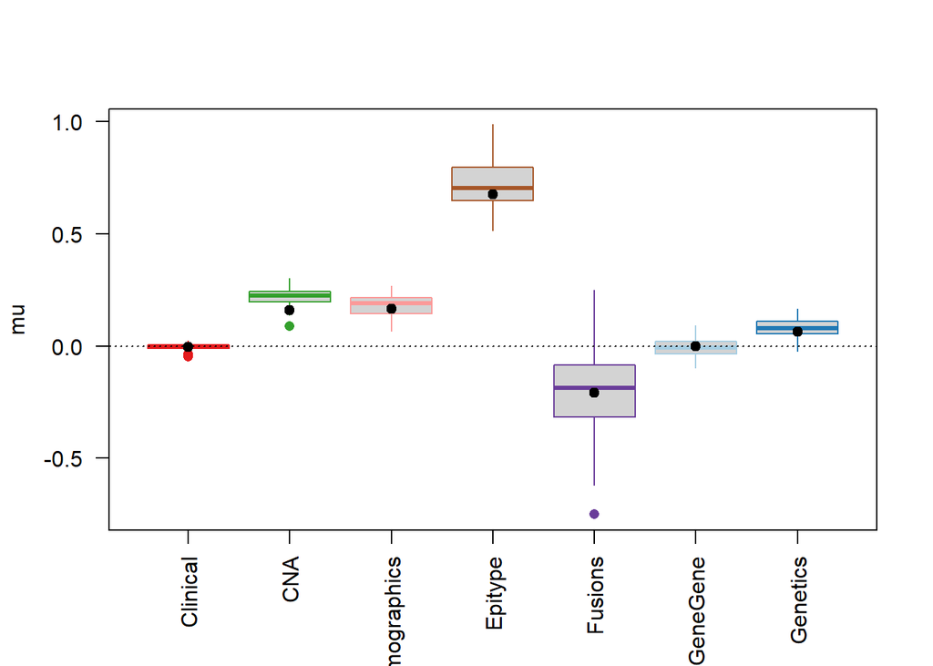

```r
boxplot(t(sapply(parBoot, `[[`, "mu")), border=colGroups[names(parBoot[[1]]$mu)], lty=1, pch=16, staplewex=0, ylab="mu", las=2)
abline(h=0, lty=3)
points(coxRFXFitOsTDGGc$mu,  pch=19)
```

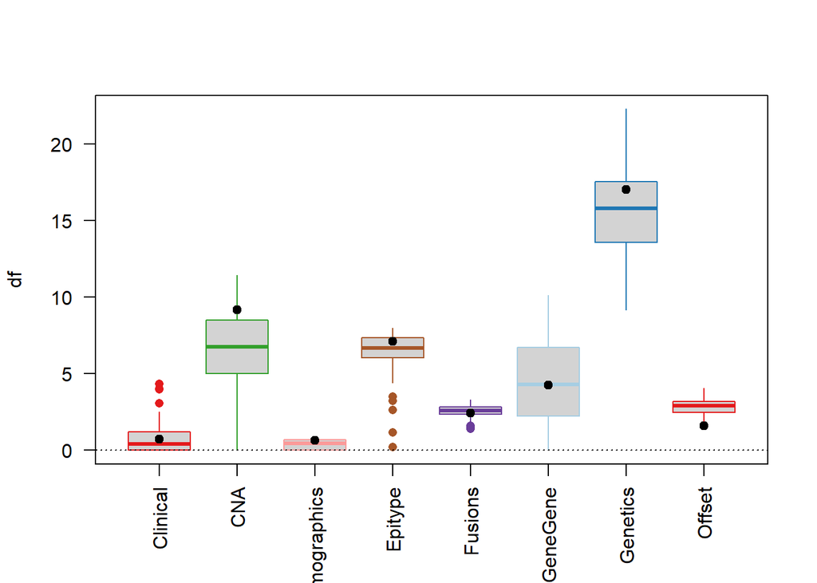

```r
boxplot(t(sapply(parBoot, `[[`, "df")), border=colGroups[names(parBoot[[1]]$mu)], lty=1, pch=16, staplewex=0, ylab="df", las=2)
abline(h=0, lty=3)
points(coxRFXFitOsTDGGc$df,  pch=19)
```

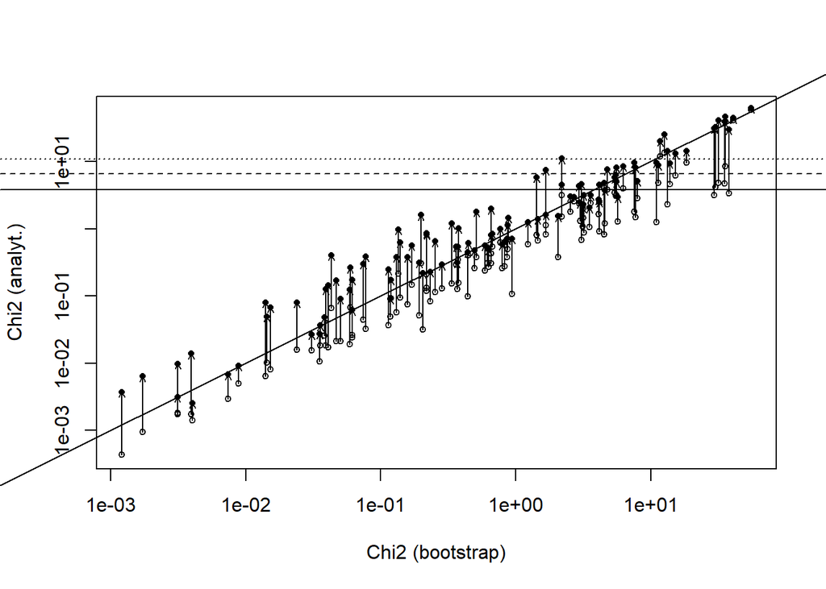

```r
#Coefficients
v <- apply(sapply(parBoot, `[[`, "coefficients"), 1, var, na.rm=TRUE)
w <- diag(coxRFXFitOsTDGGc$var) ## H^{-1}
w2 <- diag(coxRFXFitOsTDGGc$var2) ## H^{-1} I H^{-1}
c <- coef(coxRFXFitOsTDGGc)


plot(c^2/v, c^2/w, log="xy", xlab="Chi2 (bootstrap)", ylab="Chi2 (analyt.)", cex=.66)
par(xpd=NA)
points(c^2/v, c^2/w2, pch=16, cex=.7)
arrows(c^2/v, c^2/w, c^2/v,c^2/w2, length=0.05)
abline(0,1)
abline(h=qchisq(c(0.95,0.99,0.999), 1, lower.tail=TRUE), lty=c(1,2,3))
```

```r
pBoot <- pchisq(c^2/v,1, lower.tail=FALSE)
pVar2 <- pchisq(c^2/w2,1, lower.tail=FALSE)
pVar <- pchisq(c^2/w,1, lower.tail=FALSE)


MainData <- dataRaw[whichRFXOsTDGG]



waldOut <- data.frame(group = groups[whichRFXOsTDGG],
                      `beta (log-hazard)`= c,
                      `hazard exp(beta)` = exp(c),
                      n = ifelse(groups[whichRFXOsTDGG] %in% c("CNA","Fusions","Genetics","GeneGene", "Nuisance", "Epitype"),
                                 colSums(dataRaw[sub("_10*$","",names(whichRFXOsTDGG))], na.rm=TRUE), NA),

                      n2 = ifelse(groups[whichRFXOsTDGG] %in% c("Demographics","Clinical"),
                                 colSums(MainData != "", na.rm=TRUE), NA),




                      sd = sqrt(w2),

                      `sd (var)`= sqrt(w),
                      `P-value`=pVar2,
                      `Q (Benjamini-Yekutieli)` = p.adjust(pVar2, "BY"),
                      `Q (Benjamini-Hochberg)` = p.adjust(pVar2, "BH"),
                      check.names=FALSE
)


is.numeric(waldOut$n)
```

```
## [1] TRUE
```

```r
is.numeric(waldOut$n2)
```

```
## [1] TRUE
```

```r
waldOut$n2[is.na(waldOut$n2)] <- 0
waldOut$n[is.na(waldOut$n)] <- 0

waldOut$n <- waldOut$n + waldOut$n2

waldOut <- waldOut[,-5]



datatable(as.data.frame(lapply(waldOut, function(x) if(class(x)=="numeric") round(x,4) else x),
                        check.names=FALSE, row.names=row.names(waldOut)))
```

|  | group | beta (log-hazard) | hazard exp(beta) | n | sd | sd (var) | P-value | Q (Benjamini-Yekutieli) | Q (Benjamini-Hochberg) |
| --- | --- | --- | --- | --- | --- | --- | --- | --- | --- |
| ASXL1 | Genetics | -0.0204 | 0.9798 | 68 | 0.0931 | 0.1276 | 0.8262 | 1 | 0.9145 |
| BCOR | Genetics | 0.0965 | 1.1014 | 63 | 0.0973 | 0.1223 | 0.3209 | 1 | 0.6374 |
| BRAF | Genetics | -0.0579 | 0.9437 | 6 | 0.0863 | 0.1856 | 0.5024 | 1 | 0.7438 |
| CBL | Genetics | 0.0575 | 1.0591 | 21 | 0.1031 | 0.1625 | 0.5774 | 1 | 0.7919 |
| DNMT3A | Genetics | 0.0583 | 1.06 | 266 | 0.0792 | 0.1075 | 0.4621 | 1 | 0.7198 |
| ETV6 | Genetics | 0.0817 | 1.0852 | 25 | 0.1026 | 0.1553 | 0.4259 | 1 | 0.7198 |
| EZH2 | Genetics | 0.0085 | 1.0085 | 27 | 0.1036 | 0.1564 | 0.9346 | 1 | 0.9599 |
| GATA2 | Genetics | 0.0098 | 1.0098 | 57 | 0.1023 | 0.1384 | 0.924 | 1 | 0.9599 |
| IDH1 | Genetics | 0.2565 | 1.2924 | 88 | 0.0881 | 0.1293 | 0.0036 | 0.1153 | 0.0217 |
| IKZF1 | Genetics | 0.0474 | 1.0486 | 20 | 0.0991 | 0.1641 | 0.6324 | 1 | 0.8192 |

[output cut: 104 more lines]

```r
waldOutDataTable <- as.data.frame(lapply(waldOut, function(x) if(class(x)=="numeric") round(x,4) else x),
                                  check.names=FALSE, row.names=row.names(waldOut))

#write.csv(waldOutDataTable, file= "Alliance with epi componant hazards min occurence 25 09292021.csv")
```

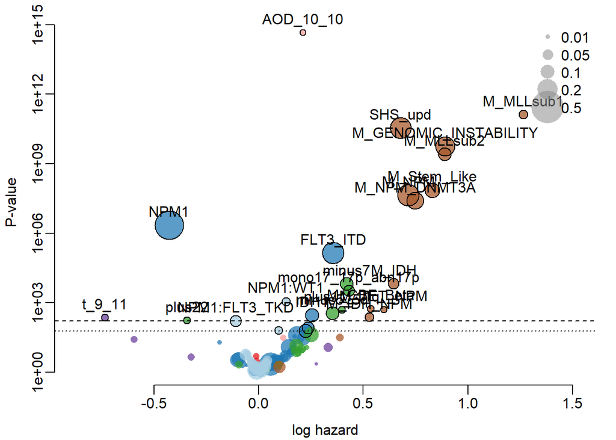

```r
#Volcano plot[]
par(mar=c(3,3,1,1)+.1,  bty="n", mgp=c(2,.5,0))
i <- coxRFXFitOsTDGGc$groups %in% c("Genetics", "CNA","Fusions","GeneGene", "Nuisance", "Epitype")#apply(coxRFXFitOsTDGGc$Z,2,min) == 0 & apply(coxRFXFitOsTDGGc$Z,2,max) == 1
p <- pVar2 ## pvalues coxRFX

plot(c, 1/p, log='y', col=paste(colGroups[as.character(coxRFXFitOsTDGGc$groups)],"BB", sep=""), pch=ifelse(i,16,16), ylab="P-value",xlab="log hazard", cex=ifelse(i, sqrt(colMeans(coxRFXFitOsTDGGc$Z)*50),1), xlim=range(c*1.2))
#abline(h=qchisq(c(0.95,0.99,0.999), 1, lower.tail=TRUE), lty=c(1,2,3))
w <- which(p.adjust(p,"BH") < 0.1)
points(c[w], 1/p[w],  pch=1, cex=ifelse(i[w], sqrt(colMeans(coxRFXFitOsTDGGc$Z[,w])*50),1))
w <- which(p.adjust(p,"BH") < 0.05)
par(xpd=NA)
text(c[w], 1/p[w], names(c[w]), pos=3)
u <- par("usr")
f <- c(0.01,0.05,0.1,0.2,0.5)
s <- sqrt(f*50)
legend("topright",legend=f, pch=16, pt.cex=s, bty='n', col=paste("#88888888"))
par(xpd=FALSE)
#abline(h=1/0.05, lty=2)
abline(h=1/max(p[which(p.adjust(p,"BH") < 0.05)]), lty=2)
abline(h=1/max(p[which(p.adjust(p,"BH") < 0.1)]), lty=3)
```

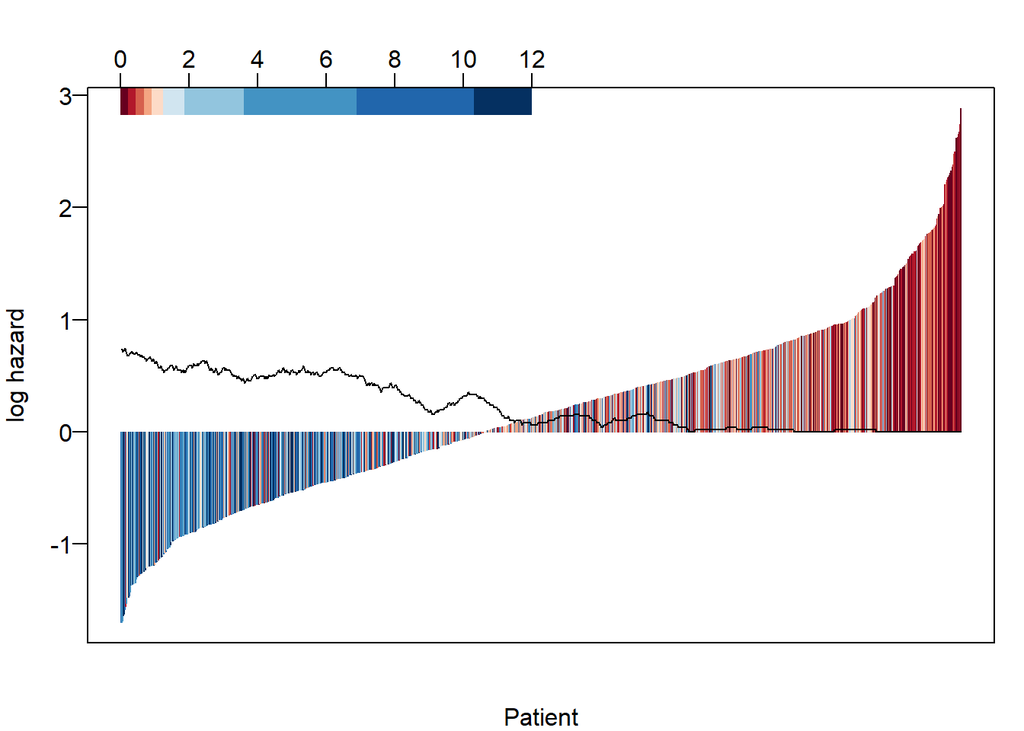

```r
#Plot of log hazard v outcome
par(mar=c(3,3,3,1), mgp=c(2,.5,0))
t <- os
s <- survfit(os~1)
q <- quantile(t[,1], seq(0,1,.1))# q <- splinefun( s$surv, s$time,"monoH.FC")(seq(1,min(s$surv),l=10))
c <- cut(t[,1], q, na.rm=TRUE)
h <- coxRFXFitOsTDGGc$linear.predictors
o <- order(h)

plot(h[o], col= (brewer.pal(10,'RdBu'))[c[o]], type='h', xaxt="n", xlab='Patient', las=2, ylab="log hazard")
u <- par("usr")
q <- pmin(q,365*12)
image(x=q/max(q)*500, y=c(u[4]-(u[4]-u[3])/20, u[4]), matrix(1:10), col= (brewer.pal(10,'RdBu')), add=TRUE)
#axis(side=3, at=seq(1,500,l=11), labels=seq(0,1,.1))
axis(side=3, at=pretty(q/365)/max(q)*365*500, labels=pretty(q/365))
lines(ksmooth(seq_along(o),t[o,2]==0, bandwidth=50))
```

Multistage Model predictor

```r
library(msSurv)
library(dplyr)

#if (!requireNamespace("BiocManager", quietly = TRUE))
#  install.packages("BiocManager")

#BiocManager::install("graph")


#outcome data
os_ms <- read.csv("endpoints_final.csv", header = TRUE, check.names = FALSE, stringsAsFactors = FALSE, row.names = 1)
os_ms <- filter(os_ms, rownames(os_ms) %in% rownames(Clin_new))
#head(os_ms)
#rownames(os_ms) <- os_ms$Sample

#os_ms <- filter(os_ms, !rownames(os_ms) %in% patientsdrop)




os_ms <- os_ms[,!(names(os_ms) %in% drop)]
#head(os_ms)

os_new <- os_ms
#head(os_new)





for (i in 2:ncol(os_new)){os_new[,i] <- as.numeric(as.character(os_new[,i]))}

#try with as.numeric(os_new$Erdate[i]) = 0 - time for first visit - they changed from dates to time periods
#so recoding is needed and date isn't the correct thing to use.

d <- sapply(1:nrow(os_new), function(i){
  i <<- i
  t <- c(as.numeric(os_new[i,c("time_to_cr","time_to_relapse","time_to_fu")]) - 0)
  o <- order(t, na.last=NA)
  stages <- c(1:3,0)
  r <- stages[c(1, o+1)]
  if(os_new$sstat[i])
    r[length(r)] <- r[length(r)-1] +3
  tt <- c(0,t[o])
  if(length(o)==0)
    return(c(rep(NA,7),i))
  s <- cbind(id=i, stop=tt[-1], start.stage=r[-length(r)], end.stage=r[-1])[diff(tt)!=0,]
  #s <- cbind(time1 = tt[-length(tt)], time2=tt[-1], death=c(rep(0, length(o)-1), osDATA$Status[i]), outer(0:(length(o)-1), r[-3], `>=`)+0, i=i)[diff(tt)!=0,]
  return(s)
})

# had problems something with the erdate variable - made it zero which is what they have and now it works


d <- as.data.frame(do.call("rbind",d))
nodes <- as.character(1:6)
edges <- list(`1`=list(edges=c("2","4")), `2`=list(edges=c("3","5")), `3`=list(edges="6"), `4`=list(edges=NULL),
              `5`=list(edges=NULL),`6`=list(edges=NULL))
struct <- new("graphNEL", nodes = nodes, edgeL = edges, edgemode = "directed")
msurv <- msSurv(d, struct, bs = FALSE)
```

```
##
## Entry distributions calculated for states 2 3 4 5 6 .
##
## Exit distributions calculated for states 1 2 3 .
```

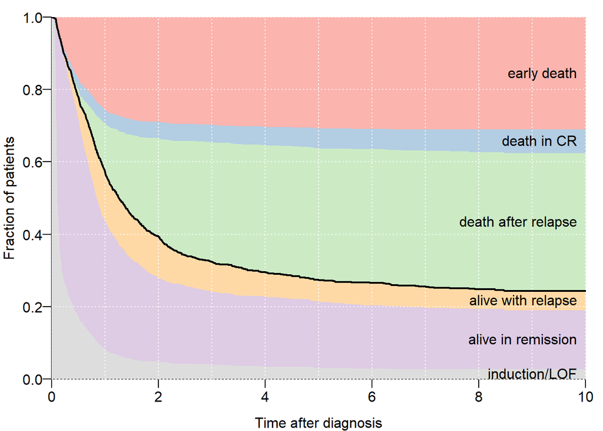

```r
y <- t(apply(cbind(1,-msurv@ps[,c(4:6, 3:1)]),1,cumsum))
par(mar=c(3,3,1,1), bty="n", mgp=c(2,.5,0), las=1)
plot(msurv@et/365.25, y[,1], ylim=c(0,1), type="s",lty=0, xlab="Time after diagnosis", ylab="Fraction of patients", xlim=c(0,10), xaxs="i", yaxs="i")
steps <- function(x, type="s") rep(x, each=2)[if(type=="s") -1 else -2*length(x)]
x <- steps(msurv@et/365.25, type="S")
for(i in 1:6)
  polygon(c(x, rev(x)), c(steps(y[,i]), rev(steps(y[,i+1])) ), col=c(brewer.pal(5,"Pastel1")[c(1:3,5,4)],"#DDDDDD")[i], border=NA)
abline(h=seq(0,1,.2), col='white', lty=3)
abline(v=seq(0,10,1), col='white', lty=3)
lines(x, steps(y[,4]), lwd=2)
w <- which.min(abs(msurv@et/365.25-10))
text(x=par("usr")[2], y= y[w,-7]+diff(y[w,])/2, labels=c("early death","death in CR","death after relapse","alive with relapse","alive in remission","induction/LOF"), pos=2)
```

setup for the multistage stuff so that we can get the individual end states plots

```r
library(CoxHD)
alloTimeCR1 <- os_new$time_to_cr + .5 # +.5 to make > 0

whichRFXRel <- whichRFXOsTDGG[grep("TPL",names(whichRFXOsTDGG), invert=TRUE)]

t <- os_new$time_to_relapse
t[is.na(t)] <- as.Date(1e6, origin="2000-01-01")


relData <- MakeTimeDependent(dataFrame[whichRFXRel], timeEvent=alloTimeCR1,
                    timeStop=as.numeric(pmin(t, os_new$time_to_fu) - os_new$time_to_cr),
                    status=!is.na(os_new$time_to_relapse)+0)


nrdData <- MakeTimeDependent(dataFrame[whichRFXRel], timeEvent=alloTimeCR1,
                             timeStop=as.numeric(pmin(t, os_new$time_to_fu) - os_new$time_to_cr),
                             status=is.na(os_new$time_to_relapse) & os_new$sstat)

alloTimeRel <- os_new$time_relapse + .5 # +.5 to make > 0





i <- !is.na(os_new$time_to_relapse)
prdData <- MakeTimeDependent(dataFrame[i,whichRFXRel], timeEvent=alloTimeRel[i],
                             timeStop=as.numeric(os_new$time_to_fu - os_new$time_to_relapse)[i],
                             status=os_new$sstat[i])

w <- which(prdData$time1 == prdData$time2) ## 5 cases with LF=Rec
prdData$time2[w] <- prdData$time2[w] + .5




crGroups <- c(as.character(groups[whichRFXRel]))
names(crGroups) <- c(names(dataFrame)[whichRFXRel])




coxRFXNrdTD <- CoxRFX(nrdData[names(crGroups)], Surv(nrdData$time1, nrdData$time2, nrdData$status),
                      groups=crGroups,nu=1, which.mu = NULL)  ## Relpaced intersect(mainGroups, unique(crGroups)) with NULL to get it to work

coxRFXPrdTD <- CoxRFX(prdData[names(crGroups)], Surv(prdData$time1, prdData$time2, prdData$status),
                      groups=crGroups, nu=1, which.mu = intersect(mainGroups, unique(crGroups)))
#takes a few seconds to run above


coxRFXRelTD <- CoxRFX(relData[names(crGroups)], Surv(relData$time1, relData$time2, relData$status),
                      groups=crGroups,nu=1, which.mu = intersect(mainGroups, unique(crGroups)))

#added nu=1 to get coefficients that are not NA
#takes a few seconds to run above


osData2 <- MakeTimeDependent(dataFrame[whichRFXRel], timeEvent=alloTimeCR1, timeStop=as.numeric(os_new$time_to_fu - os_new$time_to_cr), status=os_new$sstat)

## Quick fix to make sure all columns are the same

coxRFXOsCR <- CoxRFX(osData2[names(crGroups)], Surv(osData2$time1, osData2$time2, osData2$status),
                     groups=crGroups, which.mu = intersect(mainGroups, unique(crGroups)))

table(CR=!is.na(os_new$time_to_cr), os[,2])
```

```
##
## CR        0   1
##   FALSE  27 318
##   TRUE  214 462
```

```r
c <- as.numeric(os_new$time_to_cr - 0)
c[is.na(c)] <- os_new$time_to_fu[is.na(c)]
cr <- Surv(c, factor(pmin(2 * (!is.na(os_new$time_to_cr))+os[,2],2), levels=0:2,
                     labels=c("cens","ED","CR")), type="mstate")
coxRFXCrTD <- CoxRFX(osData2[1:1021, names(crGroups)], Surv(cr[,1], cr[,2]==2), groups=crGroups,nu=1,
                     which.mu = intersect(mainGroups, unique(crGroups)))
coxRFXNcdTD <- CoxRFX(osData2[1:1021, names(crGroups)], Surv(cr[,1], cr[,2]==1), groups=crGroups, nu = 1,  which.mu = intersect(mainGroups, unique(crGroups)))

#replaced which.mu=NULL with nu=1 to get coefficients that are not NA
```

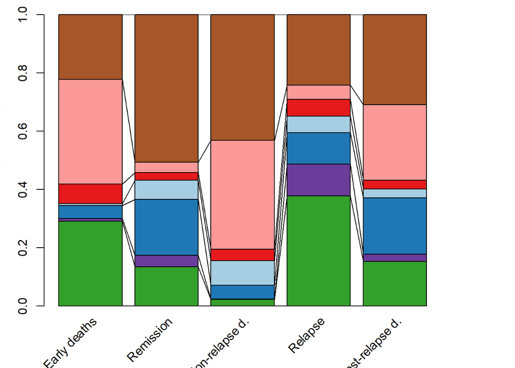

```r
par(mar=c(4,3,1,5))
allVarComp <- sapply(c("NcdTD","CrTD","NrdTD","RelTD","PrdTD"), function(x){
  m <- get(paste0("coxRFX",x))
  Z <- get(sub("\\[.+","",as.character(m$call["data"])))
  i <- if(x%in%c("CrTD","EsTD")) 1:1021 else Z$index
  VarianceComponents(m, newZ=Z[!rev(duplicated(rev(i))),colnames(m$Z)])})
colnames(allVarComp) <- c("Early deaths","Remission","Non-relapse d.","Relapse","Post-relapse d.")
w <- c("CNA","Fusions","Genetics","GeneGene","Clinical","Demographics", "Epitype")
z <- allVarComp[w,]/rep(colSums(allVarComp[-8,]), each=7)
b <- barplot(z, col=colGroups[w], ylab="Variance [log hazard]", names.arg=rep("",ncol(z)))
rotatedLabel(x0=b, labels=colnames(z))
Z <- rbind(0,apply(z,2,cumsum))
n <- ncol(z)
segments(b[-n]+.5,t(Z[,-n]),b[-1]-.5 ,t(Z[,-1]))
```

```r
colSums(allVarComp[-9,])
```

```
##    Early deaths       Remission  Non-relapse d.         Relapse Post-relapse d.
##       0.4493676       0.3563420       0.5113668       0.5604495       0.3818522
```

```r
z <- allVarComp[w,]/rep(colSums(allVarComp[-8,]), each=7)

z
```

```
##              Early deaths  Remission Non-relapse d.    Relapse Post-relapse d.
## CNA           0.290380928 0.13507108    0.022806519 0.37759015      0.15336044
## Fusions       0.010443579 0.03847821    0.001190334 0.10911945      0.02423424
## Genetics      0.044017217 0.19295421    0.047524387 0.10760784      0.19344745
## GeneGene      0.006918834 0.06566008    0.083567773 0.05676704      0.03033401
## Clinical      0.066216007 0.02562669    0.040067047 0.05751369      0.03014995
## Demographics  0.359992054 0.03526791    0.373278877 0.04956543      0.25929303
## Epitype       0.222031382 0.50694183    0.431565063 0.24183641      0.30918088
```

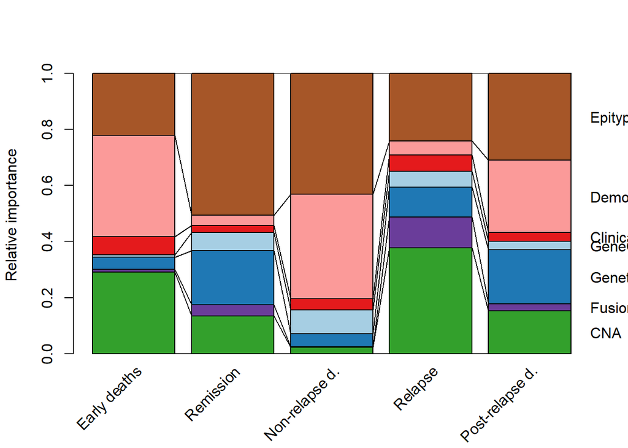

```r
b <- barplot(z, col=colGroups[w], ylab="Relative importance", names.arg=rep("",ncol(z)))
rotatedLabel(x0=b, labels=colnames(z))
Z <- rbind(0,apply(z,2,cumsum))
n <- ncol(z)
segments(b[-n]+.5,t(Z[,-n]),b[-1]-.5 ,t(Z[,-1]))
mtext(side=4, at=Z[-1,n] - diff(Z[,n])/2, text=rownames(Z)[-1], las=2)
```

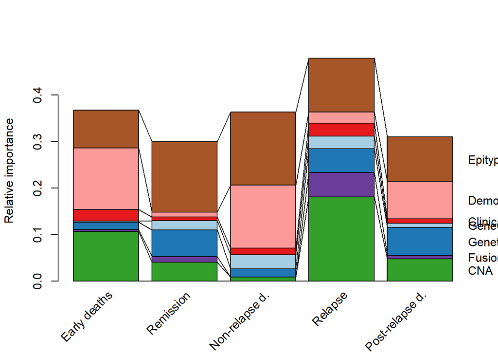

```r
z <- allVarComp[w,]

v <- c(1,3,5,4,2)
b <- barplot(z, col=colGroups[w], ylab="Relative importance", names.arg=rep("",ncol(z)))
rotatedLabel(x0=b, labels=colnames(z))
Z <- rbind(0,apply(z,2,cumsum))
n <- ncol(z)
segments(b[-n]+.5,t(Z[,-n]),b[-1]-.5 ,t(Z[,-1]))
mtext(side=4, at=Z[-1,n] - diff(Z[,n])/2, text=rownames(Z)[-1], las=2)
```

Models concordance

```r
coxRFXPrdTD$concordance
```

```
##   concordant   discordant       tied.x       tied.y      tied.xy  concordance
## 6.398000e+04 3.029900e+04 0.000000e+00 1.870000e+02 0.000000e+00 6.786241e-01
##          std
## 1.461060e-02
```

```r
coxRFXNrdTD$concordance
```

```
##   concordant   discordant       tied.x       tied.y      tied.xy  concordance
## 2.117400e+04 8.256000e+03 0.000000e+00 4.000000e+00 0.000000e+00 7.194699e-01
##          std
## 3.442175e-02
```

```r
coxRFXRelTD$concordance
```

```
##   concordant   discordant       tied.x       tied.y      tied.xy  concordance
## 1.297150e+05 5.375000e+04 0.000000e+00 1.780000e+02 0.000000e+00 7.070286e-01
##          std
## 1.237069e-02
```

```r
coxRFXNcdTD$concordance
```

```
##   concordant   discordant       tied.x       tied.y      tied.xy  concordance
## 5.546300e+04 2.280800e+04 0.000000e+00 1.160000e+02 0.000000e+00 7.086022e-01
##          std
## 1.559119e-02
```

```r
coxRFXOsCR$concordance
```

```
##   concordant   discordant       tied.x       tied.y      tied.xy  concordance
## 1.406230e+05 6.134700e+04 0.000000e+00 9.400000e+01 0.000000e+00 6.962569e-01
##          std
## 1.236895e-02
```

Relapse data Volcano plot and table

```r
osRel <- Surv(relData$time1, relData$time2, relData$status)

#relData2 <- relData[,-c(113:118)]  #change columns to delete
relData2 <- relData[,names(coxRFXRelTD$coefficients)]

whichRFX <- which((colSums(relData2)>= 0))

set.seed(42)
risk <- as.matrix(relData2) %*% coxRFXRelTD$coefficients
risk <- risk - mean(risk)
```

#########this takes time################### parBoot1 <- mclapply(1:100, function(i) { s <- SimSurvNonp(risk, osRel) c <- try(CoxRFX(relData2[whichRFX], s, groups=groups[whichRFX], sigma0=0.1, nu=0)) if(inherits(c, “try-error”)) return(s) c$Z <- NULL # set X to zero to save mem return(c) } )

save(parBoot1, file = “parBoot1Epi_Protocolyear.Rda” )

```r
load(file = "parBoot1Epi_Protocolyear.Rda")
```

```r
w <- diag(coxRFXRelTD$var) ## H^{-1}
w2 <- diag(coxRFXRelTD$var2) ## H^{-1} I H^{-1}
c <- coef(coxRFXRelTD)
```

```r
pBoot <- pchisq(c^2/v,1, lower.tail=FALSE)
pVar2 <- pchisq(c^2/w2,1, lower.tail=FALSE)
pVar <- pchisq(c^2/w,1, lower.tail=FALSE)

Quack <- dataRaw[whichRFXRel]


waldOut1 <- data.frame(group = groups[whichRFXRel],
                      `beta (log-hazard)`= c,
                      `hazard exp(beta)` = exp(c),
                      n = ifelse(groups[whichRFXRel] %in% c("CNA","Fusions","Genetics","GeneGene", "Nuisance", "Epitype"),
                                 colSums(dataRaw[sub("_10*$","",names(whichRFXRel))], na.rm=TRUE), NA),

                      n2 = ifelse(groups[whichRFXRel] %in% c("Demographics","Clinical"),
                                 colSums(Quack != "", na.rm=TRUE), NA),
                      sd = sqrt(w2),

                      `sd (var)`= sqrt(w),
                      `P-value`=pVar2,
                      `Q (Benjamini-Yekutieli)` = p.adjust(pVar2, "BY"),
                      `Q (Benjamini-Hochberg)` = p.adjust(pVar2, "BH"),
                      check.names=FALSE
)



waldOut1$n2[is.na(waldOut1$n2)] <- 0
waldOut1$n[is.na(waldOut1$n)] <- 0

waldOut1$n <- waldOut1$n + waldOut1$n2

waldOut1 <- waldOut1[,-5]





datatable(as.data.frame(lapply(waldOut1, function(x) if(class(x)=="numeric") round(x,4) else x), check.names=FALSE
                        , row.names=row.names(waldOut1)))
```

|  | group | beta (log-hazard) | hazard exp(beta) | n | sd | sd (var) | P-value | Q (Benjamini-Yekutieli) | Q (Benjamini-Hochberg) |
| --- | --- | --- | --- | --- | --- | --- | --- | --- | --- |
| ASXL1 | Genetics | 0.0175 | 1.0176 | 68 | 0.1086 | 0.1847 | 0.8721 | 1 | 0.9447 |
| BCOR | Genetics | -0.2433 | 0.7841 | 63 | 0.1179 | 0.1701 | 0.0391 | 0.6971 | 0.1311 |
| BRAF | Genetics | -0.0938 | 0.9104 | 6 | 0.0937 | 0.2263 | 0.3166 | 1 | 0.5553 |
| CBL | Genetics | -0.0836 | 0.9198 | 21 | 0.1158 | 0.2092 | 0.47 | 1 | 0.734 |
| DNMT3A | Genetics | 0.1158 | 1.1228 | 266 | 0.1027 | 0.1555 | 0.2597 | 1 | 0.4935 |
| ETV6 | Genetics | 0.0721 | 1.0748 | 25 | 0.1132 | 0.2016 | 0.5241 | 1 | 0.776 |
| EZH2 | Genetics | 0.0042 | 1.0042 | 27 | 0.1213 | 0.1947 | 0.9726 | 1 | 0.9924 |
| GATA2 | Genetics | 0.0116 | 1.0117 | 57 | 0.117 | 0.1783 | 0.9211 | 1 | 0.9634 |
| IDH1 | Genetics | 0.2012 | 1.2229 | 88 | 0.0988 | 0.1835 | 0.0417 | 0.7225 | 0.1359 |
| IKZF1 | Genetics | 0.0072 | 1.0073 | 20 | 0.1063 | 0.2108 | 0.9458 | 1 | 0.9802 |

[output cut: 104 more lines]

```r
waldOutDataTable1 <- as.data.frame(lapply(waldOut1, function(x) if(class(x)=="numeric") round(x,4) else x), check.names=FALSE, row.names=row.names(waldOut))
```

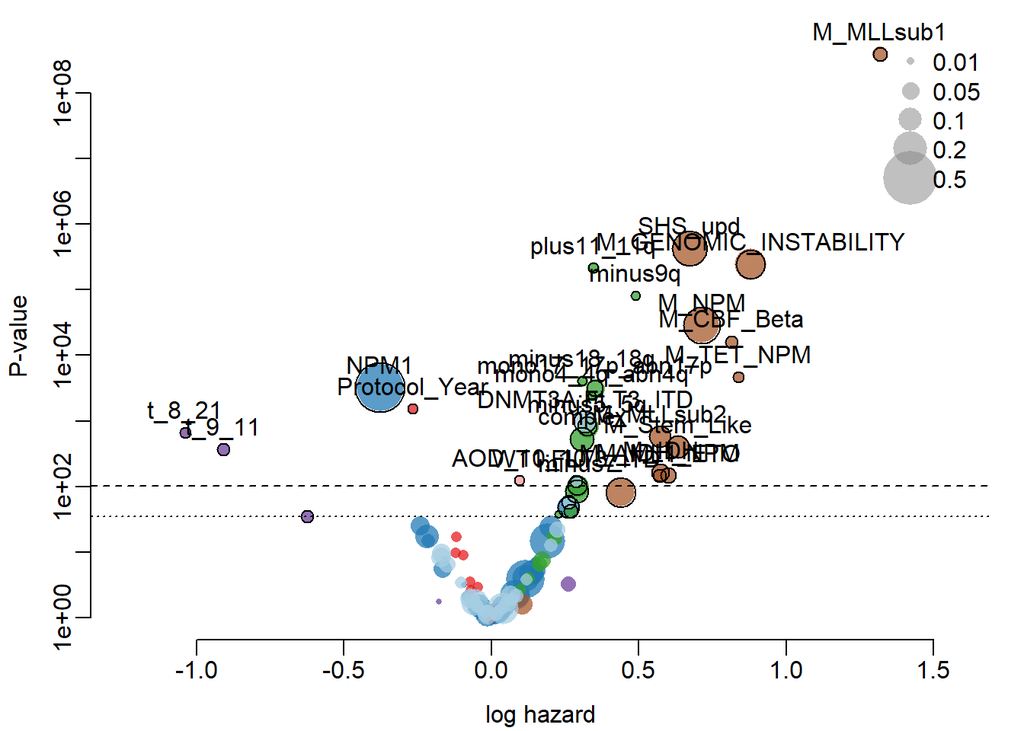

```r
#Volcano plot

par(mar=c(3,3,1,1)+.1,  bty="n", mgp=c(2,.5,0))
par(mfrow=c(1,1))

i <- coxRFXRelTD$groups %in% c("Genetics", "CNA","Fusions","GeneGene","Epitype")#apply(coxRFXFitOsTDGGc$Z,2,min) == 0 & apply(coxRFXFitOsTDGGc$Z,2,max) == 1
p <- pVar2 ## pvalues coxRFX
plot(c, 1/p, log='y', col=paste(colGroups[as.character(coxRFXRelTD$groups)],"BB", sep=""), pch=ifelse(i,16,16), ylab="P-value",xlab="log hazard", cex=ifelse(i, sqrt(colMeans(coxRFXFitOsTDGGc$Z)*50),1), xlim=range(c*1.2))
#abline(h=qchisq(c(0.95,0.99,0.999), 1, lower.tail=TRUE), lty=c(1,2,3))
w <- which(p.adjust(p,"BH") < 0.1)
points(c[w], 1/p[w],  pch=1, cex=ifelse(i[w], sqrt(colMeans(coxRFXRelTD$Z[,w])*50),1))
w <- which(p.adjust(p,"BH") < 0.05)
par(xpd=NA)
text(c[w], 1/p[w], names(c[w]), pos=3)
u <- par("usr")
f <- c(0.01,0.05,0.1,0.2,0.5)
s <- sqrt(f*50)
legend("topright",legend=f, pch=16, pt.cex=s, bty='n', col=paste("#88888888"))
par(xpd=FALSE)
#abline(h=1/0.05, lty=2)
abline(h=1/max(p[which(p.adjust(p,"BH") < 0.05)]), lty=2)
abline(h=1/max(p[which(p.adjust(p,"BH") < 0.1)]), lty=3)
```

Post relapse Data Volcano plot and Table

```r
library(survival)
#this worked with the dataset wtih 1252 pts on 7/22/2021


osPrd <- survival::Surv(prdData$time1, prdData$time2, prdData$status)

mainGroups <- grep("[A-Z][a-z]+[A-Z]",levels(groups), invert=TRUE, value=TRUE)
mainGroups
```

```
## [1] "Clinical"     "CNA"          "Demographics" "Epitype"      "Fusions"
## [6] "Genetics"
```

```r
mainIdx <- groups %in% mainGroups
```

library(survival)

osPrd <- survival::Surv(prdData$time1, prdData$time2, prdData$status)

prdData2 <- prdData[,names(coxRFXPrdTD$coefficients)] #change columns to delete mainGroups <- grep(“[A-Z][a-z]+[A-Z]”,levels(groups), invert=TRUE, value=TRUE) mainGroups

mainIdx <- groups %in% mainGroups whichRFX <- which((colSums(prdData2)>= 0) ) #removed |MainIdx

set.seed(42) risk <- as.matrix(prdData2) %*% coxRFXPrdTD$coefficients risk <- risk - mean(risk)

SimSurvNonpS <- function(risk, surv, H0 = basehaz(coxph(surv ~ 1))) { H0 = basehaz(coxph(os ~ 1)) FHazInv <- splinefun(c(0,H0$hazard), c(0,H0$time), method=“monoH.FC”, ties=min) n = length(risk) deathTimes = FHazInv(rexp(n, exp(risk))) #predict(hazardDist, rexp(n, exp(risk))) }

f <- os f[,2] <- 1-f[,2] F <- survfit(f~1) FCensInv <- splinefun(F$surv, F$time, ties=min ) censTimes <- FCensInv(runif(n,0,1)) ## Simulate censoring times

survOut <- Surv(time = pmax(0,pmin(deathTimes, censTimes)), event=(deathTimes < censTimes)+0) return(survOut) }

parBoot2 <- mclapply(1:100, function(i) { s <- SimSurvNonpS(risk, osPrd) c <- try(CoxRFX(prdData2[whichRFX], s, groups=groups[whichRFX], sigma0=0.1, nu=0)) if(inherits(c, “try-error”)) return(s) c$Z <- NULL # set X to zero to save mem return(c) } ) save(parBoot2, file = “parBoot2Epi.Rda”)

```r
load(file = "parBoot2Epi.Rda")

w <- diag(coxRFXPrdTD$var) ## H^{-1}
w2 <- diag(coxRFXPrdTD$var2) ## H^{-1} I H^{-1}
c <- coef(coxRFXPrdTD)
```

```r
pBoot <- pchisq(c^2/v,1, lower.tail=FALSE)
```

```r
pVar2 <- pchisq(c^2/w2,1, lower.tail=FALSE)
pVar <- pchisq(c^2/w,1, lower.tail=FALSE)



Quack <- dataRaw[whichRFXRel]


waldOut2 <- data.frame(group = groups[whichRFXRel],
                      `beta (log-hazard)`= c,
                      `hazard exp(beta)` = exp(c),
                      n = ifelse(groups[whichRFXRel] %in% c("CNA","Fusions","Genetics","GeneGene", "Nuisance", "Epitype"),
                                 colSums(dataRaw[sub("_10*$","",names(whichRFXRel))], na.rm=TRUE), NA),

                      n2 = ifelse(groups[whichRFXRel] %in% c("Demographics","Clinical"),
                                 colSums(Quack != "", na.rm=TRUE), NA),
                      sd = sqrt(w2),

                      `sd (var)`= sqrt(w),
                      `P-value`=pVar2,
                      `Q (Benjamini-Yekutieli)` = p.adjust(pVar2, "BY"),
                      `Q (Benjamini-Hochberg)` = p.adjust(pVar2, "BH"),
                      check.names=FALSE
)


waldOut2$n2[is.na(waldOut2$n2)] <- 0
waldOut2$n[is.na(waldOut2$n)] <- 0

waldOut2$n <- waldOut2$n + waldOut2$n2

waldOut2 <- waldOut2[,-5]




datatable(as.data.frame(lapply(waldOut2, function(x) if(class(x)=="numeric") round(x,4) else x), check.names=FALSE
                        , row.names=row.names(waldOut2)))
```

|  | group | beta (log-hazard) | hazard exp(beta) | n | sd | sd (var) | P-value | Q (Benjamini-Yekutieli) | Q (Benjamini-Hochberg) |
| --- | --- | --- | --- | --- | --- | --- | --- | --- | --- |
| ASXL1 | Genetics | 0.0723 | 1.075 | 68 | 0.1082 | 0.1806 | 0.5042 | 1 | 0.7873 |
| BCOR | Genetics | 0.2104 | 1.2342 | 63 | 0.1128 | 0.177 | 0.0622 | 1 | 0.2955 |
| BRAF | Genetics | 0.0585 | 1.0602 | 6 | 0.0721 | 0.2251 | 0.4175 | 1 | 0.7458 |
| CBL | Genetics | 0.2984 | 1.3477 | 21 | 0.0783 | 0.2257 | 0.0001 | 0.0418 | 0.0079 |
| DNMT3A | Genetics | -0.0089 | 0.9911 | 266 | 0.0981 | 0.152 | 0.9276 | 1 | 0.9442 |
| ETV6 | Genetics | 0.1473 | 1.1587 | 25 | 0.1086 | 0.1986 | 0.1749 | 1 | 0.478 |
| EZH2 | Genetics | 0.1115 | 1.118 | 27 | 0.1099 | 0.1957 | 0.3102 | 1 | 0.6801 |
| GATA2 | Genetics | 0.0371 | 1.0378 | 57 | 0.1128 | 0.1781 | 0.7424 | 1 | 0.9004 |
| IDH1 | Genetics | 0.3455 | 1.4127 | 88 | 0.0989 | 0.1779 | 0.0005 | 0.0479 | 0.009 |
| IKZF1 | Genetics | 0.1088 | 1.115 | 20 | 0.1057 | 0.2071 | 0.3031 | 1 | 0.6776 |

[output cut: 104 more lines]

```r
waldOutDataTable2 <- as.data.frame(lapply(waldOut2, function(x) if(class(x)=="numeric") round(x,4) else x), check.names=FALSE, row.names=row.names(waldOut2))
```

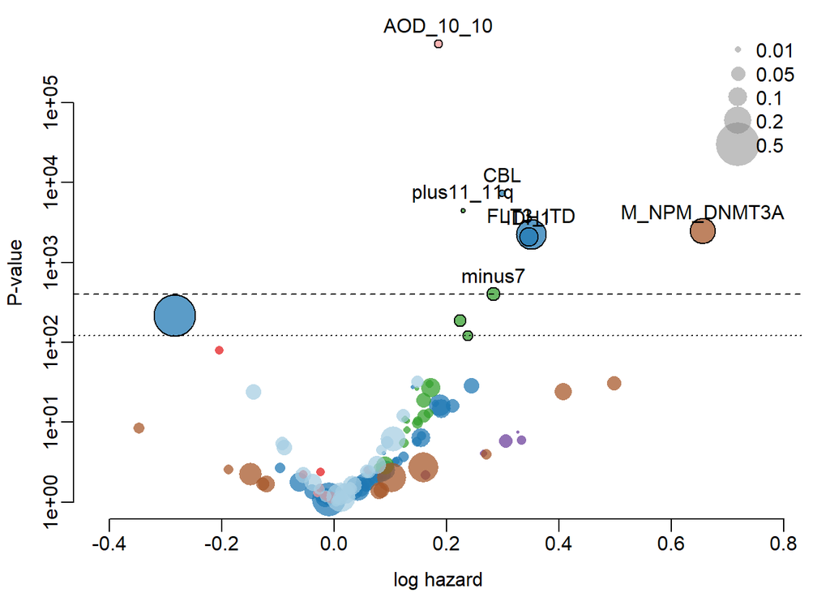

```r
#Volcano plot
par(mar=c(3,3,1,1)+.1,  bty="n", mgp=c(2,.5,0))
par(mfrow=c(1,1))

i <- coxRFXPrdTD$groups %in% c("Genetics", "CNA","Fusions","GeneGene", "Nuisance", "Epitype")#apply(coxRFXFitOsTDGGc$Z,2,min) == 0 & apply(coxRFXFitOsTDGGc$Z,2,max) == 1
p <- pVar2 ## pvalues coxRFX
plot(c, 1/p, log='y', col=paste(colGroups[as.character(coxRFXPrdTD$groups)],"BB", sep=""), pch=ifelse(i,16,16), ylab="P-value",xlab="log hazard", cex=ifelse(i, sqrt(colMeans(coxRFXPrdTD$Z)*50),1), xlim=range(c*1.2))
#abline(h=qchisq(c(0.95,0.99,0.999), 1, lower.tail=TRUE), lty=c(1,2,3))
w <- which(p.adjust(p,"BH") < 0.1)
points(c[w], 1/p[w],  pch=1, cex=ifelse(i[w], sqrt(colMeans(coxRFXPrdTD$Z[,w])*50),1))
w <- which(p.adjust(p,"BH") < 0.05)
par(xpd=NA)
text(c[w], 1/p[w], names(c[w]), pos=3)
u <- par("usr")
f <- c(0.01,0.05,0.1,0.2,0.5)
s <- sqrt(f*50)
legend("topright",legend=f, pch=16, pt.cex=s, bty='n', col=paste("#88888888"))
par(xpd=FALSE)
#abline(h=1/0.05, lty=2)
abline(h=1/max(p[which(p.adjust(p,"BH") < 0.05)]), lty=2)
abline(h=1/max(p[which(p.adjust(p,"BH") < 0.1)]), lty=3)
```

Complete Remission data volcano plot and table

```r
library(survival)
osData3 <- osData2[1:1014, names(crGroups)]

whichRFX <- which((colSums(osData3)>= 0)  )    #| mainIdx


set.seed(42)
risk <- as.matrix(osData3) %*% coxRFXCrTD$coefficients
risk <- risk - mean(risk)


osCR <- survival::Surv(cr[,1], cr[,2]==2)
```

parBoot3 <- mclapply(1:100, function(i) { s <- SimSurvNonpS(risk, osCR) c <- try(CoxRFX(osData3[whichRFX], s, groups=groups[whichRFX], sigma0=0.1, nu=0)) if(inherits(c, “try-error”)) return(s) c$Z <- NULL # set X to zero to save mem return(c) } )

save(parBoot3, file = “parBoot3Epi.Rda”)

```r
load(file = "parBoot3Epi.Rda")


w <- diag(coxRFXCrTD$var) ## H^{-1}
w2 <- diag(coxRFXCrTD$var2) ## H^{-1} I H^{-1}
c <- coef(coxRFXCrTD)
```

```r
pBoot <- pchisq(c^2/v,1, lower.tail=FALSE)
```

```r
pVar2 <- pchisq(c^2/w2,1, lower.tail=FALSE)
pVar <- pchisq(c^2/w,1, lower.tail=FALSE)


Quack <- dataRaw[whichRFXRel]


waldOut3 <- data.frame(group = groups[whichRFXRel],
                      `beta (log-hazard)`= c,
                      `hazard exp(beta)` = exp(c),
                      n = ifelse(groups[whichRFXRel] %in% c("CNA","Fusions","Genetics","GeneGene", "Nuisance", "Epitype"),
                                 colSums(dataRaw[sub("_10*$","",names(whichRFXRel))], na.rm=TRUE), NA),

                      n2 = ifelse(groups[whichRFXRel] %in% c("Demographics","Clinical"),
                                 colSums(Quack != "", na.rm=TRUE), NA),
                      sd = sqrt(w2),

                      `sd (var)`= sqrt(w),
                      `P-value`=pVar2,
                      `Q (Benjamini-Yekutieli)` = p.adjust(pVar2, "BY"),
                      `Q (Benjamini-Hochberg)` = p.adjust(pVar2, "BH"),
                      check.names=FALSE
)



waldOut3$n2[is.na(waldOut3$n2)] <- 0
waldOut3$n[is.na(waldOut3$n)] <- 0

waldOut3$n <- waldOut3$n + waldOut3$n2

waldOut3 <- waldOut3[,-5]





datatable(as.data.frame(lapply(waldOut3, function(x) if(class(x)=="numeric") round(x,4) else x), check.names=FALSE
                        , row.names=row.names(waldOut3)))
```

|  | group | beta (log-hazard) | hazard exp(beta) | n | sd | sd (var) | P-value | Q (Benjamini-Yekutieli) | Q (Benjamini-Hochberg) |
| --- | --- | --- | --- | --- | --- | --- | --- | --- | --- |
| ASXL1 | Genetics | -0.0768 | 0.9261 | 68 | 0.1018 | 0.155 | 0.4507 | 1 | 0.7555 |
| BCOR | Genetics | -0.1478 | 0.8626 | 63 | 0.1082 | 0.1449 | 0.172 | 1 | 0.4491 |
| BRAF | Genetics | -0.0532 | 0.9482 | 6 | 0.0857 | 0.2022 | 0.5351 | 1 | 0.8197 |
| CBL | Genetics | 0.115 | 1.1219 | 21 | 0.1041 | 0.1825 | 0.2693 | 1 | 0.5482 |
| DNMT3A | Genetics | -0.1321 | 0.8762 | 266 | 0.0892 | 0.1318 | 0.1387 | 1 | 0.4054 |
| ETV6 | Genetics | -0.1046 | 0.9007 | 25 | 0.107 | 0.1719 | 0.3285 | 1 | 0.604 |
| EZH2 | Genetics | -0.0014 | 0.9986 | 27 | 0.109 | 0.1643 | 0.9894 | 1 | 0.9894 |
| GATA2 | Genetics | -0.0232 | 0.9771 | 57 | 0.1023 | 0.1449 | 0.8206 | 1 | 0.9426 |
| IDH1 | Genetics | -0.092 | 0.9121 | 88 | 0.0935 | 0.1501 | 0.3252 | 1 | 0.604 |
| IKZF1 | Genetics | -0.0278 | 0.9726 | 20 | 0.1042 | 0.1808 | 0.7897 | 1 | 0.9426 |

[output cut: 104 more lines]

```r
waldOutDataTable3 <- as.data.frame(lapply(waldOut3, function(x) if(class(x)=="numeric") round(x,4) else x), check.names=FALSE, row.names=row.names(waldOut3))
```

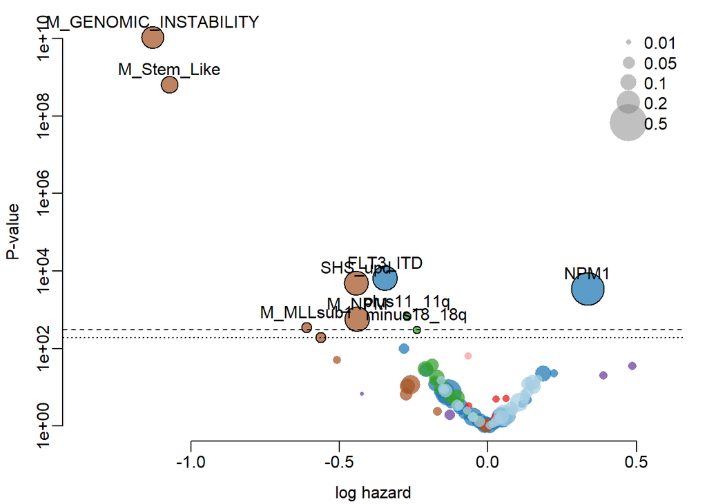

```r
#Volcano plot
par(mar=c(3,3,1,1)+.1,  bty="n", mgp=c(2,.5,0))
par(mfrow=c(1,1))

i <- coxRFXCrTD$groups %in% c("Genetics", "CNA","Fusions","GeneGene", "Nuisance", "Epitype")
p <- pVar2 ## pvalues coxRFX
plot(c, 1/p, log='y', col=paste(colGroups[as.character(coxRFXCrTD$groups)],"BB", sep=""), pch=ifelse(i,16,16), ylab="P-value",xlab="log hazard", cex=ifelse(i, sqrt(colMeans(coxRFXCrTD$Z)*50),1), xlim=range(c*1.2))
#abline(h=qchisq(c(0.95,0.99,0.999), 1, lower.tail=TRUE), lty=c(1,2,3))
w <- which(p.adjust(p,"BH") < 0.1)
points(c[w], 1/p[w],  pch=1, cex=ifelse(i[w], sqrt(colMeans(coxRFXCrTD$Z[,w])*50),1))
w <- which(p.adjust(p,"BH") < 0.05)
par(xpd=NA)
text(c[w], 1/p[w], names(c[w]), pos=3)
u <- par("usr")
f <- c(0.01,0.05,0.1,0.2,0.5)
s <- sqrt(f*50)
legend("topright",legend=f, pch=16, pt.cex=s, bty='n', col=paste("#88888888"))
par(xpd=FALSE)
#abline(h=1/0.05, lty=2)
abline(h=1/max(p[which(p.adjust(p,"BH") < 0.05)]), lty=2)
abline(h=1/max(p[which(p.adjust(p,"BH") < 0.1)]), lty=3)
```

Non-complete remission death

```r
library(survival)


osNcd <- survival::Surv(cr[,1], cr[,2]==1)
osData3 <- osData2[1:1014, names(crGroups)]

whichRFX <- which((colSums(osData3)>= 0))

set.seed(42)
risk <- as.matrix(osData3) %*% coxRFXNcdTD$coefficients
risk <- risk - mean(risk)
```

parBoot4 <- mclapply(1:100, function(i) { s <- SimSurvNonpS(risk, osNcd) c <- try(CoxRFX(osData3[whichRFX], s, groups=groups[whichRFX], sigma0=0.1, nu=0)) if(inherits(c, “try-error”)) return(s) c$Z <- NULL # set X to zero to save mem return(c) } )

save(parBoot4, file = “parBoot4Epi.Rda”)

```r
load(file = "parBoot4Epi.Rda")


w <- diag(coxRFXNcdTD$var) ## H^{-1}
w2 <- diag(coxRFXNcdTD$var2) ## H^{-1} I H^{-1}
c <- coef(coxRFXNcdTD)
pVar2 <- pchisq(c^2/w2,1, lower.tail=FALSE)
pVar <- pchisq(c^2/w,1, lower.tail=FALSE)
```

```r
Quack <- dataRaw[whichRFXRel]


waldOut4 <- data.frame(group = groups[whichRFXRel],
                      `beta (log-hazard)`= c,
                      `hazard exp(beta)` = exp(c),
                      n = ifelse(groups[whichRFXRel] %in% c("CNA","Fusions","Genetics","GeneGene",  "Epitype"),
                                 colSums(dataRaw[sub("_10*$","",names(whichRFXRel))], na.rm=TRUE), NA),

                      n2 = ifelse(groups[whichRFXRel] %in% c("Demographics","Clinical"),
                                 colSums(Quack != "", na.rm=TRUE), NA),
                      sd = sqrt(w2),

                      `sd (var)`= sqrt(w),
                      `P-value`=pVar2,
                      `Q (Benjamini-Yekutieli)` = p.adjust(pVar2, "BY"),
                      `Q (Benjamini-Hochberg)` = p.adjust(pVar2, "BH"),
                      check.names=FALSE
)




waldOut4$n2[is.na(waldOut4$n2)] <- 0
waldOut4$n[is.na(waldOut4$n)] <- 0

waldOut4$n <- waldOut4$n + waldOut4$n2

waldOut4 <- waldOut4[,-5]






datatable(as.data.frame(lapply(waldOut4, function(x) if(class(x)=="numeric") round(x,4) else x), check.names=FALSE
                        , row.names=row.names(waldOut4)))
```

|  | group | beta (log-hazard) | hazard exp(beta) | n | sd | sd (var) | P-value | Q (Benjamini-Yekutieli) | Q (Benjamini-Hochberg) |
| --- | --- | --- | --- | --- | --- | --- | --- | --- | --- |
| ASXL1 | Genetics | -0.0888 | 0.9151 | 68 | 0.0883 | 0.1414 | 0.3151 | 1 | 0.8822 |
| BCOR | Genetics | 0.0766 | 1.0796 | 63 | 0.094 | 0.1414 | 0.4156 | 1 | 0.8822 |
| BRAF | Genetics | -0.0024 | 0.9976 | 6 | 0.0619 | 0.182 | 0.9691 | 1 | 0.9892 |
| CBL | Genetics | 0.0407 | 1.0416 | 21 | 0.0756 | 0.1719 | 0.5903 | 1 | 0.8822 |
| DNMT3A | Genetics | 0.0153 | 1.0154 | 266 | 0.0822 | 0.1344 | 0.8524 | 1 | 0.9816 |
| ETV6 | Genetics | -0.0363 | 0.9643 | 25 | 0.0869 | 0.1605 | 0.676 | 1 | 0.9398 |
| EZH2 | Genetics | -0.0209 | 0.9794 | 27 | 0.0815 | 0.1662 | 0.7979 | 1 | 0.9729 |
| GATA2 | Genetics | 0.0863 | 1.0902 | 57 | 0.0857 | 0.1618 | 0.3137 | 1 | 0.8822 |
| IDH1 | Genetics | 0.0163 | 1.0165 | 88 | 0.0867 | 0.1485 | 0.8506 | 1 | 0.9816 |
| IKZF1 | Genetics | 0.0166 | 1.0167 | 20 | 0.079 | 0.1681 | 0.834 | 1 | 0.9802 |

[output cut: 104 more lines]

```r
waldOutDataTable4 <- as.data.frame(lapply(waldOut4, function(x) if(class(x)=="numeric") round(x,4) else x), check.names=FALSE, row.names=row.names(waldOut4))
```

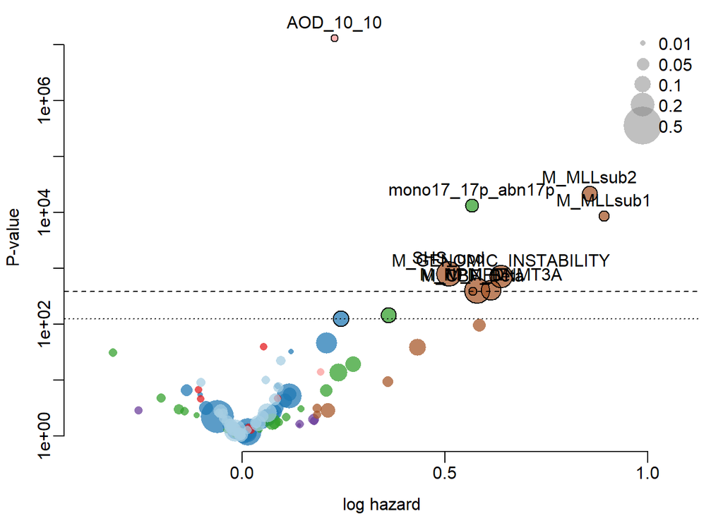

```r
#Volcano plot
par(mar=c(3,3,1,1)+.1,  bty="n", mgp=c(2,.5,0))
par(mfrow=c(1,1))

i <- coxRFXNcdTD$groups %in% c("Genetics", "CNA","Fusions","GeneGene", "Nuisance", "Epitype")
p <- pVar2 ## pvalues coxRFX
plot(c, 1/p, log='y', col=paste(colGroups[as.character(coxRFXNcdTD$groups)],"BB", sep=""), pch=ifelse(i,16,16), ylab="P-value",xlab="log hazard", cex=ifelse(i, sqrt(colMeans(coxRFXNcdTD$Z)*50),1), xlim=range(c*1.2))
#abline(h=qchisq(c(0.95,0.99,0.999), 1, lower.tail=TRUE), lty=c(1,2,3))
w <- which(p.adjust(p,"BH") < 0.1)
points(c[w], 1/p[w],  pch=1, cex=ifelse(i[w], sqrt(colMeans(coxRFXNcdTD$Z[,w])*50),1))
w <- which(p.adjust(p,"BH") < 0.05)
par(xpd=NA)
text(c[w], 1/p[w], names(c[w]), pos=3)
u <- par("usr")
f <- c(0.01,0.05,0.1,0.2,0.5)
s <- sqrt(f*50)
legend("topright",legend=f, pch=16, pt.cex=s, bty='n', col=paste("#88888888"))
par(xpd=FALSE)
#abline(h=1/0.05, lty=2)
abline(h=1/max(p[which(p.adjust(p,"BH") < 0.05)]), lty=2)
abline(h=1/max(p[which(p.adjust(p,"BH") < 0.1)]), lty=3)
```

Nonrelapse death

```r
sNrd <- Surv(nrdData$time1, nrdData$time2, nrdData$status)

nrdData2 <- nrdData[,names(coxRFXNrdTD$coefficients)]

whichRFX <- which((colSums(nrdData2)>= 0) )

set.seed(42)
risk <- as.matrix(nrdData2) %*% coxRFXNrdTD$coefficients
risk <- risk - mean(risk)
```

parBoot5 <- mclapply(1:100, function(i) { s <- SimSurvNonpS(risk, osNrd) c <- try(CoxRFX(nrdData2[whichRFX], s, groups=groups[whichRFX], sigma0=0.1, nu=0)) if(inherits(c, “try-error”)) return(s) c$Z <- NULL # set X to zero to save mem return(c) } )

save(parBoot5, file = “parBoot5Epi.Rda”)

save(parBoot5, file = “parBoot5Epi.Rda”) save(parBoot4, file = “parBoot4Epi.Rda”) save(parBoot3, file = “parBoot3Epi.Rda”) save(parBoot2, file = “parBoot2Epi.Rda”) save(parBoot1, file = “parBoot1Epi.Rda”)

```r
#load(file = "parBoot5Nuis.Rda")

w <- diag(coxRFXNrdTD$var) ## H^{-1}
w2 <- diag(coxRFXNrdTD$var2) ## H^{-1} I H^{-1}
c <- coef(coxRFXNrdTD)
```

```r
pBoot <- pchisq(c^2/v,1, lower.tail=FALSE)
```

```r
pVar2 <- pchisq(c^2/w2,1, lower.tail=FALSE)
pVar <- pchisq(c^2/w,1, lower.tail=FALSE)


#Clinical and Demographic aren't in c bc the n is large but all the pvalue info is in the table.
Quack <- dataRaw[whichRFXRel]


waldOut5 <- data.frame(group = groups[whichRFXRel],
                      `beta (log-hazard)`= c,
                      `hazard exp(beta)` = exp(c),
                      n = ifelse(groups[whichRFXRel] %in% c("CNA","Fusions","Genetics","GeneGene", "Epitype"),
                                 colSums(dataRaw[sub("_10*$","",names(whichRFXRel))], na.rm=TRUE), NA),

                      n2 = ifelse(groups[whichRFXRel] %in% c("Demographics","Clinical"),
                                 colSums(Quack != "", na.rm=TRUE), NA),
                      sd = sqrt(w2),

                      `sd (var)`= sqrt(w),
                      `P-value`=pVar2,
                      `Q (Benjamini-Yekutieli)` = p.adjust(pVar2, "BY"),
                      `Q (Benjamini-Hochberg)` = p.adjust(pVar2, "BH"),
                      check.names=FALSE
)


waldOut5$n2[is.na(waldOut5$n2)] <- 0
waldOut5$n[is.na(waldOut5$n)] <- 0

waldOut5$n <- waldOut5$n + waldOut5$n2

waldOut5 <- waldOut5[,-5]




datatable(as.data.frame(lapply(waldOut5, function(x) if(class(x)=="numeric") round(x,4) else x), check.names=FALSE
                        , row.names=row.names(waldOut5)))
```

|  | group | beta (log-hazard) | hazard exp(beta) | n | sd | sd (var) | P-value | Q (Benjamini-Yekutieli) | Q (Benjamini-Hochberg) |
| --- | --- | --- | --- | --- | --- | --- | --- | --- | --- |
| ASXL1 | Genetics | 0.0939 | 1.0985 | 68 | 0.087 | 0.2329 | 0.2802 | 1 | 0.8165 |
| BCOR | Genetics | 0.0027 | 1.0027 | 63 | 0.0876 | 0.2357 | 0.9758 | 1 | 0.9976 |
| BRAF | Genetics | 0.0125 | 1.0126 | 6 | 0.0497 | 0.2493 | 0.8016 | 1 | 0.9423 |
| CBL | Genetics | 0.0839 | 1.0875 | 21 | 0.0823 | 0.2382 | 0.308 | 1 | 0.8165 |
| DNMT3A | Genetics | -0.0445 | 0.9565 | 266 | 0.0941 | 0.216 | 0.6367 | 1 | 0.9035 |
| ETV6 | Genetics | 0.0055 | 1.0055 | 25 | 0.0561 | 0.248 | 0.9223 | 1 | 0.9976 |
| EZH2 | Genetics | -0.0094 | 0.9906 | 27 | 0.0792 | 0.2401 | 0.9053 | 1 | 0.9976 |
| GATA2 | Genetics | -0.1353 | 0.8734 | 57 | 0.087 | 0.2355 | 0.1199 | 1 | 0.7741 |
| IDH1 | Genetics | 0.1031 | 1.1086 | 88 | 0.0865 | 0.2279 | 0.2335 | 1 | 0.8165 |
| IKZF1 | Genetics | 0.0248 | 1.0251 | 20 | 0.0479 | 0.2501 | 0.6055 | 1 | 0.9035 |

[output cut: 104 more lines]

```r
waldOutDataTable5 <- as.data.frame(lapply(waldOut5, function(x) if(class(x)=="numeric") round(x,4) else x), check.names=FALSE, row.names=row.names(waldOut5))
```

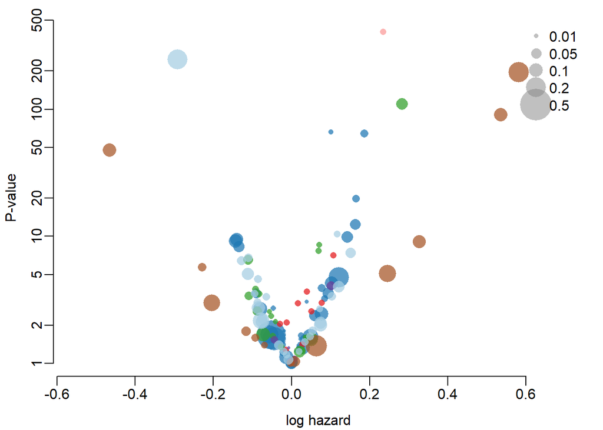

```r
#Volcano plot
par(mar=c(3,3,1,1)+.1,  bty="n", mgp=c(2,.5,0))
par(mfrow=c(1,1))

i <- coxRFXNrdTD$groups %in% c("Genetics", "CNA","Fusions","GeneGene",  "Epitype")
p <- pVar2 ## pvalues coxRFX
plot(c, 1/p, log='y', col=paste(colGroups[as.character(coxRFXNrdTD$groups)],"BB", sep=""), pch=ifelse(i,16,16), ylab="P-value",xlab="log hazard", cex=ifelse(i, sqrt(colMeans(coxRFXNrdTD$Z)*50),1), xlim=range(c*1.2))
#abline(h=qchisq(c(0.95,0.99,0.999), 1, lower.tail=TRUE), lty=c(1,2,3))
w <- which(p.adjust(p,"BH") < 0.1)
points(c[w], 1/p[w],  pch=1, cex=ifelse(i[w], sqrt(colMeans(coxRFXNrdTD$Z[,w])*50),1))
w <- which(p.adjust(p,"BH") < 0.05)
par(xpd=NA)
#text(c[w], 1/p[w], names(c[w]), pos=3)
u <- par("usr")
f <- c(0.01,0.05,0.1,0.2,0.5)
s <- sqrt(f*50)
legend("topright",legend=f, pch=16, pt.cex=s, bty='n', col=paste("#88888888"))
par(xpd=FALSE)
#abline(h=1/0.05, lty=2)
abline(h=1/max(p[which(p.adjust(p,"BH") < 0.05)]), lty=2)
abline(h=1/max(p[which(p.adjust(p,"BH") < 0.1)]), lty=3)
```